# Pertemuan 3 - Regresi dengan Peubah Lag

Indra Mahib Zuhair Riyanto

## Impor Data

```r
data <- read.csv("D:\\IPB\\5\\MPDW\\data\\tomtom_20_27.csv")
data$time <- as.POSIXct(data$time)
str(data)
```

```
## 'data.frame':    168 obs. of  7 variables:
##  $ Time        : chr  "2024-08-20 13:01:30.001" "2024-08-20 14:01:30.001" "2024-08-20 15:01:30.000" "2024-08-20 16:01:30.000" ...
##  $ time        : POSIXct, format: "2024-08-20 13:01:30" "2024-08-20 14:01:30" ...
##  $ Live.Traffic: int  44 24 14 6 0 0 0 0 0 0 ...
##  $ Travel.Time : num  125.3 108 99.1 92.5 84.4 ...
##  $ Jams.Count  : int  250 86 48 39 27 23 16 23 20 22 ...
##  $ Jams.Length : num  180.6 73.3 59.9 37.3 36.3 ...
##  $ Jams.Delay  : num  1155 390 192 223 151 ...
```

```r
data <- data %>% select(time,Travel.Time,Jams.Delay)
names(data) <- c("time","travel_time","jams_delay")
```

## Pembagian Data

```r
#SPLIT DATA
train<-data[1:134,] #134
test<-data[135:168,] #34
```

```r
#data time series
train.ts<-ts(train)
test.ts<-ts(test)
data.ts<-ts(data)
```

## Eksplorasi Data

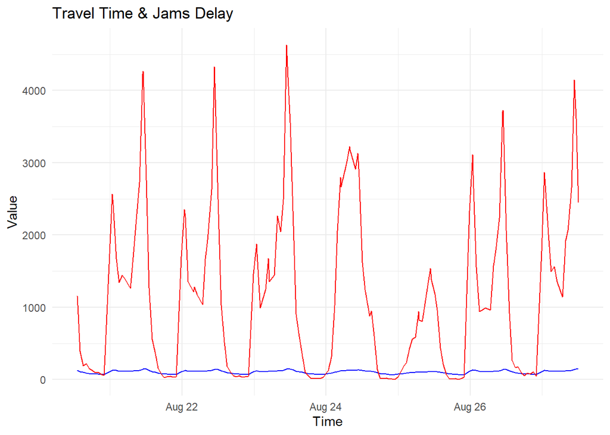

```r
ggplot(data=data)+
  geom_line(aes(x=time,y=travel_time),color="blue")+
  geom_line(aes(x=time,y=jams_delay),color="red")+
  labs(title="Travel Time & Jams Delay",x="Time",y="Value")+
  theme_minimal()
```

Pola antar kedua variabel tidak terlihat dengan jelas karena perbedaan skala, sehingga perlu dilakukan standarisasi. Standarisasi dilakukan hanya untuk bagian eksplorasi saja.

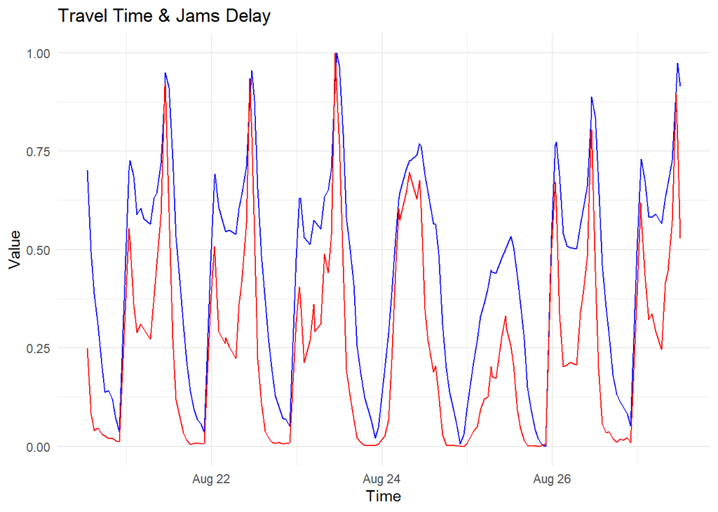

```r
#STANDARISASI
minmax <- function(x) {
  return((x - min(x)) / (max(x) - min(x)))
}

ggplot(data=data)+
  geom_line(aes(x=time,y=minmax(travel_time)),color="blue")+
  geom_line(aes(x=time,y=minmax(jams_delay)),color="red")+
  labs(title="Travel Time & Jams Delay",x="Time",y="Value")+
  theme_minimal()+
  theme(legend.position = "topleft")
```

terlihat setelah di standarisasi terdapat pola antar kedua variabel yang jelas. Selanjutnya kita dapat mencoba membuat model auto-regressive.

## Model Koyck

Model Koyck didasarkan pada asumsi bahwa semakin jauh jarak lag peubah independen dari periode sekarang maka semakin kecil pengaruh peubah lag terhadap peubah dependen.

Koyck mengusulkan suatu metode untuk menduga model dinamis distributed lag dengan mengasumsikan bahwa semua koefisien $\beta$ mempunyai tanda sama.

Model kyock merupakan jenis paling umum dari model infinite distributed lag dan juga dikenal sebagai geometric lag

$$y_t=a(1-\lambda)+\beta_0X_t+\beta_1Z_t+\lambda Y_{t-1}+V_t$$

dengan
$$V_t=u_t-\lambda
u_{t-1}$$

### Pemodelan

Pemodelan model Koyck dengan `R` dapat menggunakan `dLagM::koyckDlm()` . Fungsi umum dari `koyckDlm` adalah sebagai berikut.

```r
koyckDlm(x , y , intercept)
```

Fungsi `koyckDlm()` akan menerapkan model lag terdistribusi dengan transformasi Koyck satu prediktor. Nilai `x` dan `y` tidak perlu sebagai objek *time series* (`ts`). `intercept` dapat dibuat `TRUE` untuk memasukkan intersep ke dalam model.

```r
#MODEL KOYCK
model.koyck <- koyckDlm(x = train$jams_delay, y = train$travel_time)
summary(model.koyck)
```

```
##
## Call:
## "Y ~ (Intercept) + Y.1 + X.t"
##
## Residuals:
##     Min      1Q  Median      3Q     Max
## -7.3683 -3.9231 -0.3644  2.1622 21.7426
##
## Coefficients:
##              Estimate Std. Error t value Pr(>|t|)
## (Intercept) 30.736245   2.945218   10.44   <2e-16 ***
## Y.1          0.617262   0.034227   18.03   <2e-16 ***
## X.t          0.007621   0.000734   10.38   <2e-16 ***
## ---
## Signif. codes:  0 '***' 0.001 '**' 0.01 '*' 0.05 '.' 0.1 ' ' 1
##
## Residual standard error: 5.314 on 130 degrees of freedom
## Multiple R-Squared: 0.9447,  Adjusted R-squared: 0.9438
## Wald test:  1008 on 2 and 130 DF,  p-value: < 2.2e-16
##
## Diagnostic tests:
## NULL
##
##                             alpha        beta       phi
## Geometric coefficients:  80.30612 0.007621498 0.6172615
```

```r
AIC(model.koyck)
```

```
## [1] 826.7202
```

```r
BIC(model.koyck)
```

```
## [1] 838.2816
```

Dari hasil tersebut, didapat bahwa peubah $x_t$ dan $y_{t-1}$ memiliki nilai $P-Value<0.05$. Hal ini menunjukkan bahwa peubah $x_t$ dan $y_{t-1}$ berpengaruh signifikan terhadap $y_t$. Adapun model keseluruhannya adalah sebagai berikut

$$\hat{Y_t}=30.736+0.008X_t+0.617Y_{t-1}$$

### Peramalan dan Akurasi

Berikut adalah hasil peramalan y untuk beberapa periode kedepan menggunakan model koyck.

```r
fore.koyck <- forecast(model = model.koyck, x=test$jams_delay, h=dim(test)[1])
fore.koyck
```

```
## $forecasts
##  [1] 114.56638 108.80002 105.44950 103.14585 106.43017 110.04501 115.67474
##  [8] 130.42042 139.64279 132.68981 119.62413 106.58236  97.78908  92.46421
## [15]  88.54175  85.79817  84.36989  83.40748  83.04817  82.35003  95.09362
## [22] 111.29310 119.90301 120.07611 116.26704 114.39752 111.67123 108.35967
## [29] 112.31675 115.82707 122.48749 137.93569 143.42959 137.90666
##
## $call
## forecast.koyckDlm(model = model.koyck, x = test$jams_delay, h = dim(test)[1])
##
## attr(,"class")
## [1] "forecast.koyckDlm" "dLagM"
```

```r
mape.koyck <- MAPE(fore.koyck$forecasts, test$travel_time)
#akurasi data training
GoF(model.koyck)
```

```
##               n      MAE          MPE       MAPE     sMAPE      MASE     MSE
## model.koyck 133 3.822983 -0.005177696 0.04048381 0.0406837 0.5801149 27.6027
##                MRAE     GMRAE
## model.koyck 5.34662 0.6904459
```

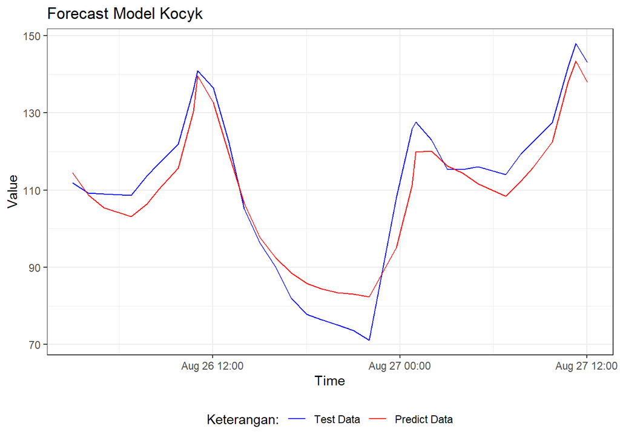

```r
ggplot(test,aes(x=time))+
  geom_line(aes(y=travel_time,col="Test Data"))+
  geom_line(aes(y=fore.koyck$forecasts,col="Predict Data"))+
  labs(title="Forecast Model Kocyk",x="Time",y="Value")+
  scale_colour_manual(name="Keterangan:", breaks = c("Test Data", "Predict Data"),
                      values = c("blue", "red")) +
  theme_bw() + theme(legend.position = "bottom",
                     plot.caption = element_text(hjust=0.5, size=12))
```

## Regression with Distributed Lag

Pemodelan model Regression with Distributed Lag dengan `R` dapat menggunakan `dLagM::dlm()` . Fungsi umum dari `dlm` adalah sebagai berikut.

```r
dlm(formula , data , x , y , q , remove )
```

Fungsi `dlm()` akan menerapkan model lag terdistribusi dengan satu atau lebih prediktor. Nilai `x` dan `y` tidak perlu sebagai objek *time series* (`ts`). $q$ adalah integer yang mewakili panjang *lag* yang terbatas.

### Pemodelan (Lag=2)

```r
model.dlm <- dlm(x = train$jams_delay,y = train$travel_time , q = 2)
summary(model.dlm)
```

```
##
## Call:
## lm(formula = model.formula, data = design)
##
## Residuals:
##     Min      1Q  Median      3Q     Max
## -14.384  -6.297   1.577   5.996  14.028
##
## Coefficients:
##              Estimate Std. Error t value Pr(>|t|)
## (Intercept) 8.073e+01  9.734e-01  82.929  < 2e-16 ***
## x.t         1.220e-02  1.254e-03   9.723  < 2e-16 ***
## x.1         9.497e-04  1.965e-03   0.483     0.63
## x.2         6.419e-03  1.271e-03   5.050 1.48e-06 ***
## ---
## Signif. codes:  0 '***' 0.001 '**' 0.01 '*' 0.05 '.' 0.1 ' ' 1
##
## Residual standard error: 7.427 on 128 degrees of freedom
## Multiple R-squared:  0.8935, Adjusted R-squared:  0.8911
## F-statistic: 358.1 on 3 and 128 DF,  p-value: < 2.2e-16
##
## AIC and BIC values for the model:
##       AIC    BIC
## 1 909.906 924.32
```

```r
AIC(model.dlm)
```

```
## [1] 909.906
```

```r
BIC(model.dlm)
```

```
## [1] 924.32
```

$$\hat{Y_t}=80.73+0.012X_t+0.0009X_{t-1}+0.0064X_{t-2}$$

### Peramalan dan Akurasi

Berikut merupakan hasil peramalan $y$ untuk beberapa periode kedepan

```r
fore.dlm <- forecast(model = model.dlm, x=test$jams_delay, h=dim(test)[1])
fore.dlm
```

```
## $forecasts
##  [1] 111.85755 103.35801  99.77500  99.56923 107.24699 110.17556 119.77540
##  [8] 139.57184 144.03110 133.30225 117.78758  98.07986  88.88113  84.76163
## [15]  83.13144  82.62298  82.47191  82.10416  82.69311  81.89205 103.11297
## [22] 117.68885 127.59956 126.21723 118.13995 114.09262 108.33849 105.94190
## [29] 114.01812 115.10287 127.48113 147.08238 145.81188 140.59159
##
## $call
## forecast.dlm(model = model.dlm, x = test$jams_delay, h = dim(test)[1])
##
## attr(,"class")
## [1] "forecast.dlm" "dLagM"
```

```r
mape.dlm <- MAPE(fore.dlm$forecasts, test$travel_time)
#akurasi data training
GoF(model.dlm)
```

```
##             n      MAE          MPE       MAPE      sMAPE      MASE      MSE
## model.dlm 132 6.302438 -0.008083669 0.06617532 0.06504479 0.9588664 53.49524
##               MRAE    GMRAE
## model.dlm 12.66596 1.308987
```

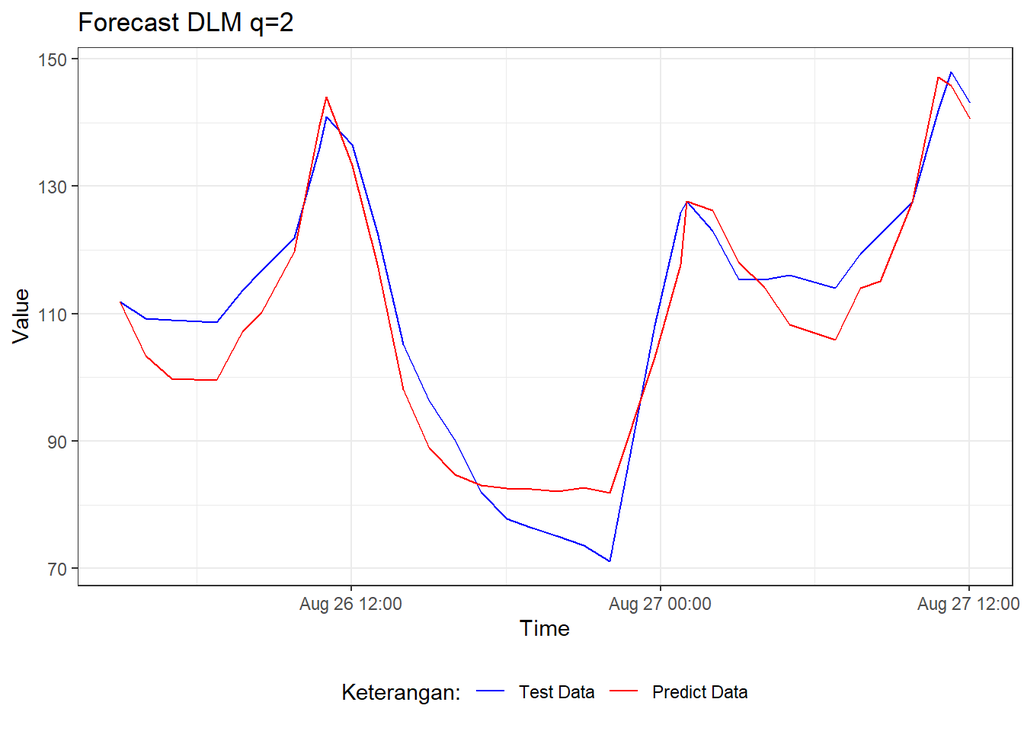

```r
ggplot(test,aes(x=time))+
  geom_line(aes(y=travel_time,col="Test Data"))+
  geom_line(aes(y=fore.dlm$forecasts,col="Predict Data"))+
  labs(title="Forecast DLM q=2",x="Time",y="Value")+
  scale_colour_manual(name="Keterangan:", breaks = c("Test Data", "Predict Data"),
                      values = c("blue", "red")) +
  theme_bw() + theme(legend.position = "bottom",
                     plot.caption = element_text(hjust=0.5, size=12))
```

### *Lag* Optimum

```r
#penentuan lag optimum
finiteDLMauto(formula = travel_time ~ jams_delay,
              data = data.frame(train), q.min = 1, q.max = 7,
              model.type = "dlm", error.type = "AIC", trace = FALSE)
```

```
##   q - k    MASE      AIC      BIC   GMRAE    MBRAE R.Adj.Sq Ljung-Box
## 7     7 0.84517 866.0968 894.5387 1.01892 -0.12702  0.90368         0
```

Berdasarkan output tersebut, lag optimum didapatkan ketika lag=7. Selanjutnya dilakukan pemodelan untuk lag=7.

```r
#model dlm dengan lag optimum
model.dlm2 <- dlm(x = train$jams_delay,y = train$travel_time , q = 7)
summary(model.dlm2)
```

```
##
## Call:
## lm(formula = model.formula, data = design)
##
## Residuals:
##     Min      1Q  Median      3Q     Max
## -17.057  -5.732   1.434   5.493  11.777
##
## Coefficients:
##               Estimate Std. Error t value Pr(>|t|)
## (Intercept) 80.3851437  1.1863878  67.756   <2e-16 ***
## x.t          0.0117587  0.0012049   9.759   <2e-16 ***
## x.1          0.0033602  0.0020049   1.676   0.0964 .
## x.2          0.0019668  0.0021553   0.913   0.3634
## x.3          0.0018259  0.0021645   0.844   0.4006
## x.4          0.0001066  0.0022308   0.048   0.9620
## x.5          0.0017444  0.0023276   0.749   0.4551
## x.6          0.0020398  0.0021834   0.934   0.3521
## x.7         -0.0029231  0.0013002  -2.248   0.0264 *
## ---
## Signif. codes:  0 '***' 0.001 '**' 0.01 '*' 0.05 '.' 0.1 ' ' 1
##
## Residual standard error: 7.021 on 118 degrees of freedom
## Multiple R-squared:  0.9098, Adjusted R-squared:  0.9037
## F-statistic: 148.8 on 8 and 118 DF,  p-value: < 2.2e-16
##
## AIC and BIC values for the model:
##        AIC      BIC
## 1 866.0968 894.5387
```

```r
AIC(model.dlm2)
```

```
## [1] 866.0968
```

```r
BIC(model.dlm2)
```

```
## [1] 894.5387
```

Dari hasil tersebut terdapat beberapa peubah yang berpengaruh signifikan terhadap taraf nyata 5% yaitu $x_t$ , dan $x_{t-7}$ . Adapun keseluruhan model yang terbentuk adalah

$$\hat{Y_t}=80.385+0.011X_t+...-0.003X_{t-7}$$

```r
#peramalan dan akurasi
fore.dlm2 <- forecast(model = model.dlm2, x=test$jams_delay, h=dim(test)[1])
mape.dlm2<- MAPE(fore.dlm2$forecasts, test$travel_time)
#akurasi data training
GoF(model.dlm2)
```

```
##              n      MAE          MPE       MAPE      sMAPE      MASE      MSE
## model.dlm2 127 5.622063 -0.006919774 0.05790815 0.05690909 0.8451736 45.80085
##                MRAE    GMRAE
## model.dlm2 14.01381 1.018919
```

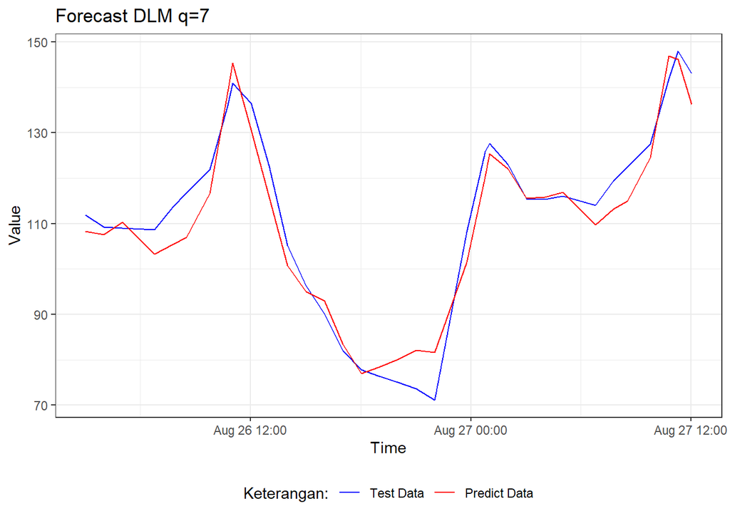

```r
ggplot(test,aes(x=time))+
  geom_line(aes(y=travel_time,col="Test Data"))+
  geom_line(aes(y=fore.dlm2$forecasts,col="Predict Data"))+
  labs(title="Forecast DLM q=7",x="Time",y="Value")+
  scale_colour_manual(name="Keterangan:", breaks = c("Test Data", "Predict Data"),
                      values = c("blue", "red")) +
  theme_bw() + theme(legend.position = "bottom",
                     plot.caption = element_text(hjust=0.5, size=12))
```

## Model Autoregressive

Peubah dependen dipengaruhi oleh peubah independen pada waktu sekarang, serta dipengaruhi juga oleh peubah dependen itu sendiri pada satu waktu yang lalu maka model tersebut disebut *autoregressive* (Gujarati 2004).

### Pemodelan

Pemodelan Autoregressive dilakukan menggunakan fungsi `dLagM::ardlDlm()` . Fungsi tersebut akan menerapkan *autoregressive* berordo $(p,q)$ dengan satu prediktor. Fungsi umum dari `ardlDlm()` adalah sebagai berikut.

```r
ardlDlm(formula = NULL , data = NULL , x = NULL , y = NULL , p = 1 , q = 1 ,
         remove = NULL )
```

Dengan $p$ adalah integer yang mewakili panjang *lag* yang terbatas dan $q$ adalah integer yang merepresentasikan ordo dari proses *autoregressive*.

```r
model.ardl <- ardlDlm(formula = travel_time ~ jams_delay,
                         data = train,p = 1 , q = 1)
summary(model.ardl)
```

```
##
## Time series regression with "ts" data:
## Start = 2, End = 134
##
## Call:
## dynlm(formula = as.formula(model.text), data = data)
##
## Residuals:
##      Min       1Q   Median       3Q      Max
## -10.8954  -3.1322  -0.6386   2.4936  15.9465
##
## Coefficients:
##                 Estimate Std. Error t value Pr(>|t|)
## (Intercept)   21.7981754  3.5628375   6.118 1.05e-08 ***
## jams_delay.t   0.0126007  0.0006869  18.344  < 2e-16 ***
## jams_delay.1  -0.0059317  0.0011032  -5.377 3.44e-07 ***
## travel_time.1  0.7140388  0.0414845  17.212  < 2e-16 ***
## ---
## Signif. codes:  0 '***' 0.001 '**' 0.01 '*' 0.05 '.' 0.1 ' ' 1
##
## Residual standard error: 4.497 on 129 degrees of freedom
## Multiple R-squared:  0.9607, Adjusted R-squared:  0.9598
## F-statistic:  1051 on 3 and 129 DF,  p-value: < 2.2e-16
```

```r
AIC(model.ardl)
```

```
## [1] 783.2759
```

```r
BIC(model.ardl)
```

```
## [1] 797.7276
```

Hasil di atas menunjukkan bahwa hasil uji t menunjukkan nilai-p pada seluruh peubah $\lt0.05$ Hal ini menunjukkan bahwa peubah $x_{t-1}$ berpengaruh signifikan terhadap $y_t$, $x_{t}$ berpengaruh signifikan terhadap $y_t$ dan $y_{t-1}$ berpengaruh signifikan terhadap $y_t$. Model keseluruhannya adalah sebagai berikut:

$$\hat{Y}=21.798+0.013X_t-0.006X_{t-1}+0.714Y_{t-1}$$

### Peramalan dan Akurasi

```r
fore.ardl <- forecast(model = model.ardl, x=test$jams_delay, h=dim(test)[1])
fore.ardl
```

```
## $forecasts
##  [1] 113.11054 109.12578 106.49171 104.05900 110.28615 113.69449 120.51124
##  [8] 141.36761 147.68718 131.19883 114.76147 101.62487  94.88965  90.82890
## [15]  86.79838  83.88213  82.48923  81.15466  80.65270  79.32404 100.52759
## [22] 119.19181 123.73598 119.56162 114.10825 114.05840 111.04841 107.43009
## [29] 116.03585 119.27544 128.18696 149.79632 149.72072 138.07456
##
## $call
## forecast.ardlDlm(model = model.ardl, x = test$jams_delay, h = dim(test)[1])
##
## attr(,"class")
## [1] "forecast.ardlDlm" "dLagM"
```

Data di atas merupakan hasil peramalan untuk 34 periode ke depan menggunakan Model Autoregressive dengan $p=1$ dan $q=1$.

```r
mape.ardl <- MAPE(fore.ardl$forecasts, test$travel_time)
mape.ardl
```

```
## [1] 0.04023714
```

```r
#akurasi data training
GoF(model.ardl)
```

```
##              n      MAE          MPE       MAPE      sMAPE     MASE      MSE
## model.ardl 133 3.454416 -0.002858448 0.03467586 0.03479841 0.524187 19.61368
##                MRAE     GMRAE
## model.ardl 5.028579 0.6589368
```

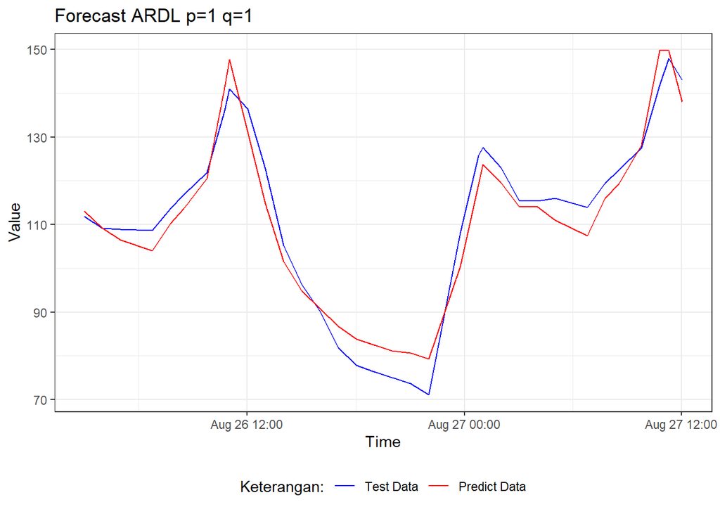

```r
ggplot(test,aes(x=time))+
  geom_line(aes(y=travel_time,col="Test Data"))+
  geom_line(aes(y=fore.ardl$forecasts,col="Predict Data"))+
  labs(title="Forecast ARDL p=1 q=1",x="Time",y="Value")+
  scale_colour_manual(name="Keterangan:", breaks = c("Test Data", "Predict Data"),
                      values = c("blue", "red")) +
  theme_bw() + theme(legend.position = "bottom",
                     plot.caption = element_text(hjust=0.5, size=12))
```

Berdasarkan akurasi di atas, terlihat bahwa nilai MAPE data test dan data latih keduanya tidak jauh berbeda. Artinya, model regresi dengan distribusi lag ini tidak `overfitted` atau `underfitted`

### *Lag* Optimum

```r
#penentuan lag optimum
model.ardl.opt <- ardlBoundOrders(data = data.frame(data), ic = "AIC",
                                  formula = travel_time ~ jams_delay )
min_p=c()
for(i in 1:6){
  min_p[i]=min(model.ardl.opt$Stat.table[[i]])
}
q_opt=which(min_p==min(min_p, na.rm = TRUE))
p_opt=which(model.ardl.opt$Stat.table[[q_opt]] ==
              min(model.ardl.opt$Stat.table[[q_opt]], na.rm = TRUE))
data.frame("q_optimum" = q_opt, "p_optimum" = p_opt,
           "AIC"=model.ardl.opt$min.Stat)
```

```
##   q_optimum p_optimum      AIC
## 1         3        15 809.6423
```

Dari tabel di atas, dapat terlihat bahwa nilai AIC terendah didapat ketika $p=15$ dan $q=3$, yaitu sebesar `809.64` Artinya, model autoregressive optimum didapat ketika $p=15$ dan $q=3$.

Selanjutnya dapat dilakukan pemodelan dengan nilai $p$ dan $q$ optimum seperti inisialisasi di langkah sebelumnya.

```r
#model ardl dengan lag optimum
ardl.opt1 <- ardlDlm(formula = travel_time ~ jams_delay,
                         data = train,p = 15 , q = 3)
summary(ardl.opt1)
```

```
##
## Time series regression with "ts" data:
## Start = 16, End = 134
##
## Call:
## dynlm(formula = as.formula(model.text), data = data)
##
## Residuals:
##     Min      1Q  Median      3Q     Max
## -6.6916 -1.9249 -0.1967  1.3777 12.3977
##
## Coefficients:
##                 Estimate Std. Error t value Pr(>|t|)
## (Intercept)   24.2986317  5.7099260   4.256 4.74e-05 ***
## jams_delay.t   0.0118327  0.0007040  16.809  < 2e-16 ***
## jams_delay.1  -0.0083784  0.0017361  -4.826 5.06e-06 ***
## jams_delay.2   0.0001938  0.0020081   0.097    0.923
## jams_delay.3   0.0017096  0.0015983   1.070    0.287
## jams_delay.4  -0.0003673  0.0012241  -0.300    0.765
## jams_delay.5   0.0019081  0.0012725   1.500    0.137
## jams_delay.6  -0.0011049  0.0012513  -0.883    0.379
## jams_delay.7  -0.0010309  0.0012476  -0.826    0.411
## jams_delay.8   0.0017021  0.0012426   1.370    0.174
## jams_delay.9  -0.0009748  0.0012489  -0.781    0.437
## jams_delay.10 -0.0012197  0.0012460  -0.979    0.330
## jams_delay.11 -0.0006524  0.0012514  -0.521    0.603
## jams_delay.12  0.0013896  0.0013083   1.062    0.291
## jams_delay.13  0.0015251  0.0013555   1.125    0.263
## jams_delay.14 -0.0012478  0.0012859  -0.970    0.334
## jams_delay.15 -0.0003822  0.0007544  -0.507    0.614
## travel_time.1  0.9738800  0.1007629   9.665 5.89e-16 ***
## travel_time.2 -0.1330524  0.1405842  -0.946    0.346
## travel_time.3 -0.1302514  0.0984962  -1.322    0.189
## ---
## Signif. codes:  0 '***' 0.001 '**' 0.01 '*' 0.05 '.' 0.1 ' ' 1
##
## Residual standard error: 3.653 on 99 degrees of freedom
## Multiple R-squared:  0.978,  Adjusted R-squared:  0.9738
## F-statistic: 231.7 on 19 and 99 DF,  p-value: < 2.2e-16
```

```r
#peramalan dan akurasi
fore.ardl.opt1 <- forecast(model = ardl.opt1, x=test$jams_delay, h=dim(test)[1])
mape.ardl.opt1 <- MAPE(fore.ardl.opt1$forecasts, test$travel_time)
mape.ardl.opt1 ## akurasi data test
```

```
## [1] 0.02628536
```

```r
#akurasi data training
GoF(ardl.opt1)
```

```
##             n     MAE         MPE       MAPE      sMAPE      MASE      MSE
## ardl.opt1 119 2.44985 -0.00159833 0.02428811 0.02429382 0.3797582 11.10172
##               MRAE    GMRAE
## ardl.opt1 5.025142 0.420476
```

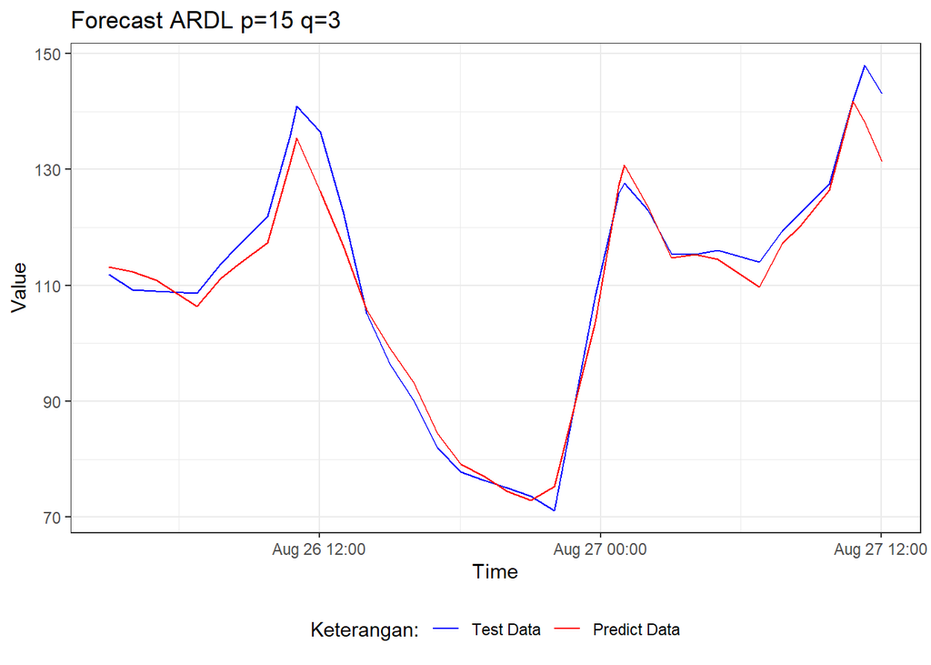

```r
ggplot(test,aes(x=time))+
  geom_line(aes(y=travel_time,col="Test Data"))+
  geom_line(aes(y=fore.ardl.opt1$forecasts,col="Predict Data"))+
  labs(title="Forecast ARDL p=15 q=3",x="Time",y="Value")+
  scale_colour_manual(name="Keterangan:", breaks = c("Test Data", "Predict Data"),
                      values = c("blue", "red")) +
  theme_bw() + theme(legend.position = "bottom",
                     plot.caption = element_text(hjust=0.5, size=12))
```

Model menunjukan prediksi yang sangat baik

## Pemodelan DLM & ARDL dengan Library `dynlm`

Pemodelan regresi dengan peubah *lag* tidak hanya dapat dilakukan dengan fungsi pada *packages* `dLagM` , tetapi terdapat *packages* `dynlm` yang dapat digunakan. Fungsi `dynlm` secara umum adalah sebagai berikut.

```r
dynlm(formula, data, subset, weights, na.action, method = "qr",
  model = TRUE, x = FALSE, y = FALSE, qr = TRUE, singular.ok = TRUE,
  contrasts = NULL, offset, start = NULL, end = NULL, ...)
```

Untuk menentukan `formula` model yang akan digunakan, tersedia fungsi tambahan yang memungkinkan spesifikasi dinamika (melalui `d()` dan `L()`) atau pola linier/siklus dengan mudah (melalui `trend()`, `season()`, dan `harmon()`). Semua fungsi formula baru mengharuskan argumennya berupa objek deret waktu (yaitu, `"ts"` atau `"zoo"`).

```r
#sama dengan model dlm q=1
cons_lm1 <- dynlm(travel_time ~ jams_delay+L(jams_delay),data = train.ts)
#sama dengan model ardl p=1 q=0
cons_lm2 <- dynlm(travel_time ~ jams_delay+L(travel_time),data = train.ts)
#sama dengan ardl p=1 q=1
cons_lm3 <- dynlm(travel_time ~ jams_delay+L(jams_delay)+L(travel_time),data = train.ts)
#sama dengan dlm p=2
cons_lm4 <- dynlm(travel_time ~ jams_delay+L(jams_delay)+L(jams_delay,2),data = train.ts)
```

### Ringkasan Model

```r
summary(cons_lm1)
```

```
##
## Time series regression with "ts" data:
## Start = 2, End = 134
##
## Call:
## dynlm(formula = travel_time ~ jams_delay + L(jams_delay), data = train.ts)
##
## Residuals:
##     Min      1Q  Median      3Q     Max
## -15.956  -7.297   1.404   6.449  14.878
##
## Coefficients:
##                Estimate Std. Error t value Pr(>|t|)
## (Intercept)   82.363843   1.010361  81.519  < 2e-16 ***
## jams_delay     0.008796   0.001176   7.478 9.97e-12 ***
## L(jams_delay)  0.009404   0.001177   7.991 6.28e-13 ***
## ---
## Signif. codes:  0 '***' 0.001 '**' 0.01 '*' 0.05 '.' 0.1 ' ' 1
##
## Residual standard error: 8.133 on 130 degrees of freedom
## Multiple R-squared:  0.8704, Adjusted R-squared:  0.8684
## F-statistic: 436.5 on 2 and 130 DF,  p-value: < 2.2e-16
```

```r
summary(cons_lm2)
```

```
##
## Time series regression with "ts" data:
## Start = 2, End = 134
##
## Call:
## dynlm(formula = travel_time ~ jams_delay + L(travel_time), data = train.ts)
##
## Residuals:
##     Min      1Q  Median      3Q     Max
## -8.7319 -3.8867 -0.1329  3.1503 17.5233
##
## Coefficients:
##                 Estimate Std. Error t value Pr(>|t|)
## (Intercept)    3.675e+01  2.455e+00   14.97   <2e-16 ***
## jams_delay     9.861e-03  5.077e-04   19.42   <2e-16 ***
## L(travel_time) 5.339e-01  2.696e-02   19.80   <2e-16 ***
## ---
## Signif. codes:  0 '***' 0.001 '**' 0.01 '*' 0.05 '.' 0.1 ' ' 1
##
## Residual standard error: 4.956 on 130 degrees of freedom
## Multiple R-squared:  0.9519, Adjusted R-squared:  0.9511
## F-statistic:  1286 on 2 and 130 DF,  p-value: < 2.2e-16
```

```r
summary(cons_lm3)
```

```
##
## Time series regression with "ts" data:
## Start = 2, End = 134
##
## Call:
## dynlm(formula = travel_time ~ jams_delay + L(jams_delay) + L(travel_time),
##     data = train.ts)
##
## Residuals:
##      Min       1Q   Median       3Q      Max
## -10.8954  -3.1322  -0.6386   2.4936  15.9465
##
## Coefficients:
##                  Estimate Std. Error t value Pr(>|t|)
## (Intercept)    21.7981754  3.5628375   6.118 1.05e-08 ***
## jams_delay      0.0126007  0.0006869  18.344  < 2e-16 ***
## L(jams_delay)  -0.0059317  0.0011032  -5.377 3.44e-07 ***
## L(travel_time)  0.7140388  0.0414845  17.212  < 2e-16 ***
## ---
## Signif. codes:  0 '***' 0.001 '**' 0.01 '*' 0.05 '.' 0.1 ' ' 1
##
## Residual standard error: 4.497 on 129 degrees of freedom
## Multiple R-squared:  0.9607, Adjusted R-squared:  0.9598
## F-statistic:  1051 on 3 and 129 DF,  p-value: < 2.2e-16
```

```r
summary(cons_lm4)
```

```
##
## Time series regression with "ts" data:
## Start = 3, End = 134
##
## Call:
## dynlm(formula = travel_time ~ jams_delay + L(jams_delay) + L(jams_delay,
##     2), data = train.ts)
##
## Residuals:
##     Min      1Q  Median      3Q     Max
## -14.384  -6.297   1.577   5.996  14.028
##
## Coefficients:
##                   Estimate Std. Error t value Pr(>|t|)
## (Intercept)      8.073e+01  9.734e-01  82.929  < 2e-16 ***
## jams_delay       1.220e-02  1.254e-03   9.723  < 2e-16 ***
## L(jams_delay)    9.497e-04  1.965e-03   0.483     0.63
## L(jams_delay, 2) 6.419e-03  1.271e-03   5.050 1.48e-06 ***
## ---
## Signif. codes:  0 '***' 0.001 '**' 0.01 '*' 0.05 '.' 0.1 ' ' 1
##
## Residual standard error: 7.427 on 128 degrees of freedom
## Multiple R-squared:  0.8935, Adjusted R-squared:  0.8911
## F-statistic: 358.1 on 3 and 128 DF,  p-value: < 2.2e-16
```

### SSE

```r
deviance(cons_lm1)
```

```
## [1] 8599.52
```

```r
deviance(cons_lm2)
```

```
## [1] 3193.21
```

```r
deviance(cons_lm3)
```

```
## [1] 2608.62
```

```r
deviance(cons_lm4)
```

```
## [1] 7061.372
```

### Uji Diagnostik

```r
#uji model
if(require("lmtest")) encomptest(cons_lm1, cons_lm2)
```

```
## Encompassing test
##
## Model 1: travel_time ~ jams_delay + L(jams_delay)
## Model 2: travel_time ~ jams_delay + L(travel_time)
## Model E: travel_time ~ jams_delay + L(jams_delay) + L(travel_time)
##           Res.Df Df       F    Pr(>F)
## M1 vs. ME    129 -1 296.259 < 2.2e-16 ***
## M2 vs. ME    129 -1  28.909  3.44e-07 ***
## ---
## Signif. codes:  0 '***' 0.001 '**' 0.01 '*' 0.05 '.' 0.1 ' ' 1
```

#### Autokorelasi

```r
#durbin watson
dwtest(cons_lm1)
```

```
##
##  Durbin-Watson test
##
## data:  cons_lm1
## DW = 0.56133, p-value < 2.2e-16
## alternative hypothesis: true autocorrelation is greater than 0
```

```r
dwtest(cons_lm2)
```

```
##
##  Durbin-Watson test
##
## data:  cons_lm2
## DW = 1.0933, p-value = 3.278e-08
## alternative hypothesis: true autocorrelation is greater than 0
```

```r
dwtest(cons_lm3)
```

```
##
##  Durbin-Watson test
##
## data:  cons_lm3
## DW = 1.2322, p-value = 1.838e-06
## alternative hypothesis: true autocorrelation is greater than 0
```

```r
dwtest(cons_lm4)
```

```
##
##  Durbin-Watson test
##
## data:  cons_lm4
## DW = 0.51779, p-value < 2.2e-16
## alternative hypothesis: true autocorrelation is greater than 0
```

#### Heterogenitas

```r
bptest(cons_lm1)
```

```
##
##  studentized Breusch-Pagan test
##
## data:  cons_lm1
## BP = 5.829, df = 2, p-value = 0.05423
```

```r
bptest(cons_lm2)
```

```
##
##  studentized Breusch-Pagan test
##
## data:  cons_lm2
## BP = 47.153, df = 2, p-value = 5.766e-11
```

```r
bptest(cons_lm3)
```

```
##
##  studentized Breusch-Pagan test
##
## data:  cons_lm3
## BP = 49.115, df = 3, p-value = 1.233e-10
```

```r
bptest(cons_lm4)
```

```
##
##  studentized Breusch-Pagan test
##
## data:  cons_lm4
## BP = 7.1967, df = 3, p-value = 0.06589
```

#### Kenormalan

```r
shapiro.test(residuals(cons_lm1))
```

```
##
##  Shapiro-Wilk normality test
##
## data:  residuals(cons_lm1)
## W = 0.94802, p-value = 6.587e-05
```

```r
shapiro.test(residuals(cons_lm2))
```

```
##
##  Shapiro-Wilk normality test
##
## data:  residuals(cons_lm2)
## W = 0.93701, p-value = 1.041e-05
```

```r
shapiro.test(residuals(cons_lm3))
```

```
##
##  Shapiro-Wilk normality test
##
## data:  residuals(cons_lm3)
## W = 0.95382, p-value = 0.0001881
```

```r
shapiro.test(residuals(cons_lm4))
```

```
##
##  Shapiro-Wilk normality test
##
## data:  residuals(cons_lm4)
## W = 0.95252, p-value = 0.0001572
```

## Perbandingan Model

```r
akurasi <- matrix(c(mape.koyck, mape.dlm, mape.dlm2, mape.ardl,mape.ardl.opt1))
row.names(akurasi)<- c("Koyck","DLM 1","DLM 2","Autoregressive","Autoregressive Optimum")
colnames(akurasi) <- c("MAPE")
akurasi
```

```
##                              MAPE
## Koyck                  0.05276249
## DLM 1                  0.04927913
## DLM 2                  0.03967686
## Autoregressive         0.04023714
## Autoregressive Optimum 0.02628536
```

Berdasarkan nilai MAPE, model paling optimum didapat pada Model Autoregressif dengan nilai `p` dan `q` optimum. karena memiliki nilai MAPE yang terkecil.

### Plot

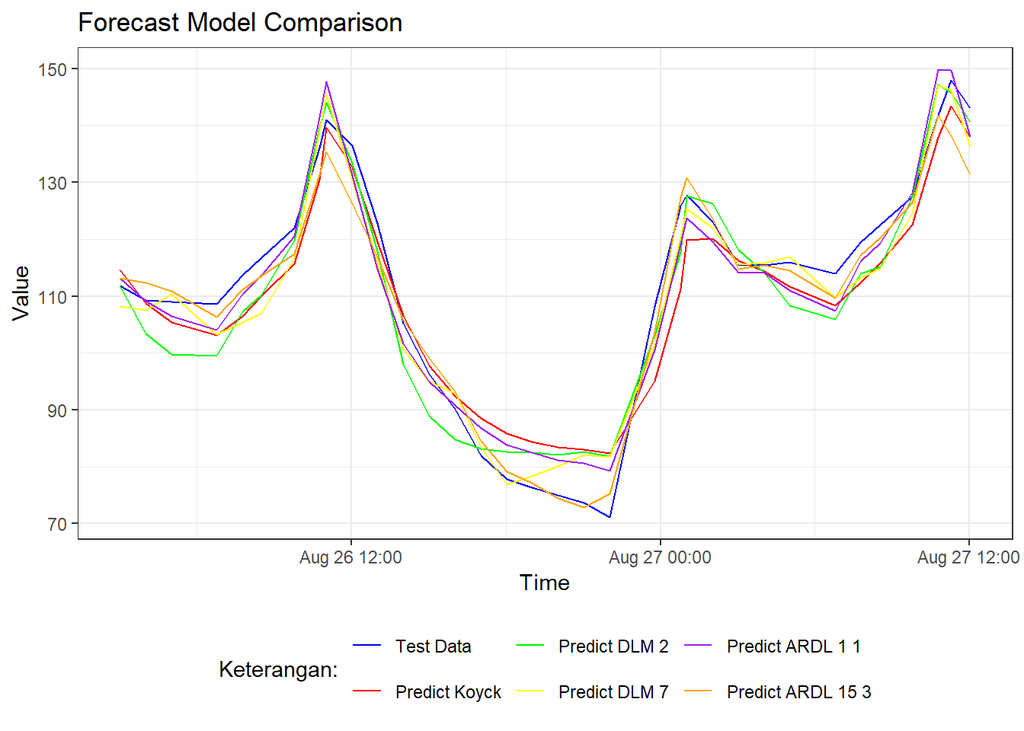

```r
## plot all hasil in test data
ggplot(test,aes(x=time),alpha=0.5)+
  geom_line(aes(y=travel_time,col="Test Data"))+
  geom_line(aes(y=fore.koyck$forecasts,col="Predict Koyck"))+
  geom_line(aes(y=fore.dlm$forecasts,col="Predict DLM 2"))+
  geom_line(aes(y=fore.dlm2$forecasts,col="Predict DLM 7"))+
  geom_line(aes(y=fore.ardl$forecasts,col="Predict ARDL 1 1"))+
  geom_line(aes(y=fore.ardl.opt1$forecasts,col="Predict ARDL 15 3"))+
  labs(title="Forecast Model Comparison",x="Time",y="Value")+
  scale_colour_manual(name="Keterangan:", breaks = c("Test Data", "Predict Koyck",
                                                    "Predict DLM 2","Predict DLM 7",
                                                    "Predict ARDL 1 1","Predict ARDL 15 3"),
                      values = c("blue", "red","green","yellow","purple","orange")) +
  theme_bw() + theme(legend.position = "bottom",
                     plot.caption = element_text(hjust=0.5, size=12))
```

Berdasarkan plot tersebut, semua model mampu memprediksi data test dengan baik. Namun, model Autoregressive dengan nilai `p` dan `q` optimum memiliki hasil yang paling baik.